# ÖNÁLLÓ ADATELEMZÉS

Csillag András Benedek

2023-07-20

## ADATTISZTÍTÁS

**Nemek ellenőrzése:**  
(férfi/nő) bevezetése a hibás értékek helyett. Ha nem férfi vagy nő szerepel a nem-nél akkor felváltva helyettesítsük oda a kettőből valamelyiket.  
**Kor ellenőrzése:**  
N/A-k, illetve a túl alacsony vagy túl magas értékek (önállóan választott határok) kiszűrése és a rajtuk kívül vett átlag behelyettesítése  
**Város ellenőrzése:**  
Megnézzük van-e üres érték… nincsen. Kigyűjtjük a város típusokat, csak értelmes érték van, innentől úgy gondolom, hogy ezzel nincs további tennivalónk  
**Testmagasság ellenőrzése:**  
N/A-k, illetve a túl alacsony vagy túl magas értékek (önállóan választott határok) kiszűrése és a rajtuk kívül vett átlag behelyettesítése  
**Jövedelem ellenőrzése:**  
N/A-k, illetve a nempozitív értékek kiszűrése és a rajtuk kívül vett átlag behelyettesítése  
**Foglalkozás ellenőrzése:**  
Megnézzük van-e üres érték… nincsen. Kigyűjtjük a foglalkozás típusokat, csak értelmes érték van, innentől úgy gondolom, hogy ezzel nincs további tennivalónk

A javított változatra summary()-t meghívva a következő eredményt kapjuk:

```r
summary(JavitottValtozat)
```

```
##      nem                 kor          varos           foglalkozas
##  Length:500         Min.   :22.0   Length:500         Length:500
##  Class :character   1st Qu.:34.0   Class :character   Class :character
##  Mode  :character   Median :44.0   Mode  :character   Mode  :character
##                     Mean   :44.3
##                     3rd Qu.:55.0
##                     Max.   :65.0
##   testmagassag     jovedelem
##  Min.   :148.0   Min.   : 153.0
##  1st Qu.:167.0   1st Qu.: 325.8
##  Median :172.0   Median : 595.5
##  Mean   :172.9   Mean   : 682.8
##  3rd Qu.:179.0   3rd Qu.: 947.0
##  Max.   :202.0   Max.   :3003.0
```

## LEÍRÓ STATISZTIKA

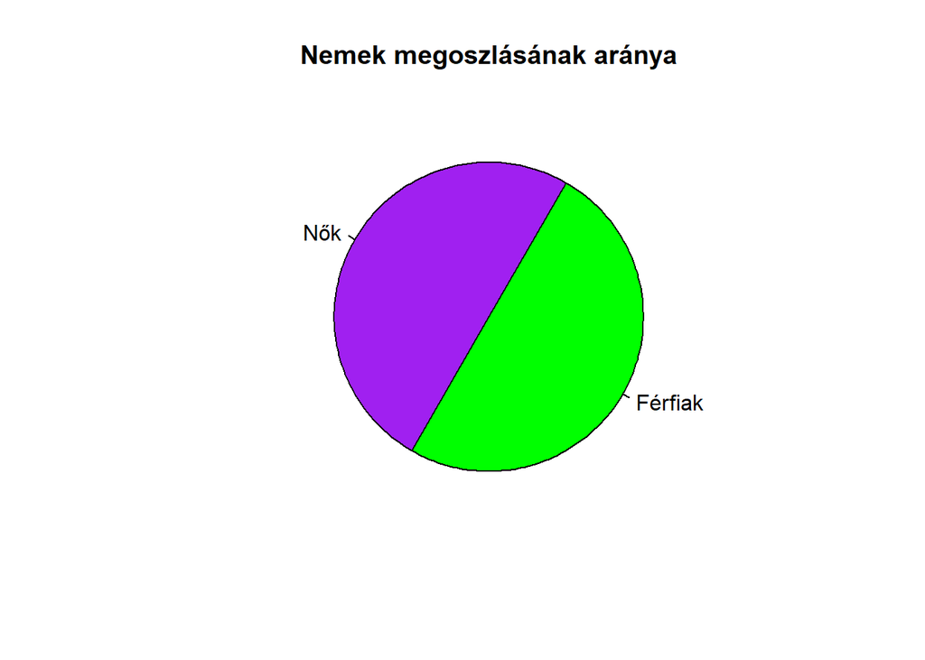

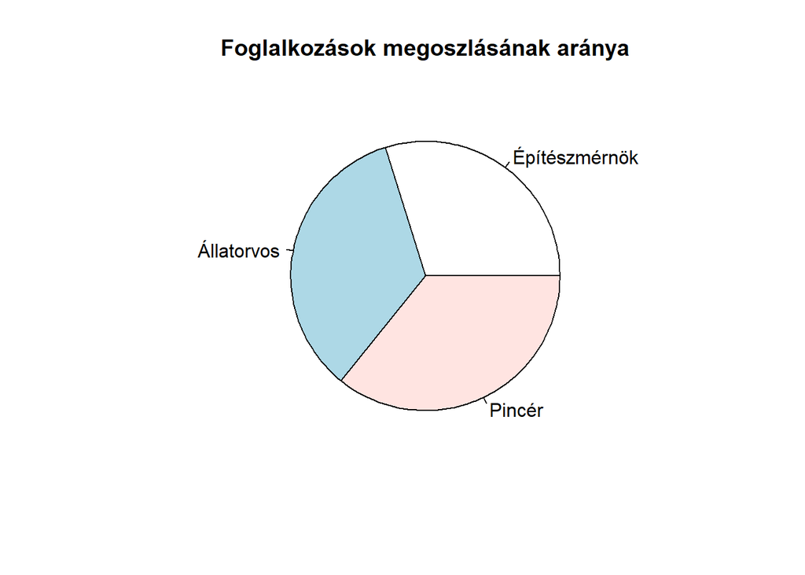

*Foglalkozások nagyjából egyenlően oszlanak el, az építészmérnökök száma valamivel kisebb, mint a az állatorvosoké, illetve pincéreké.*

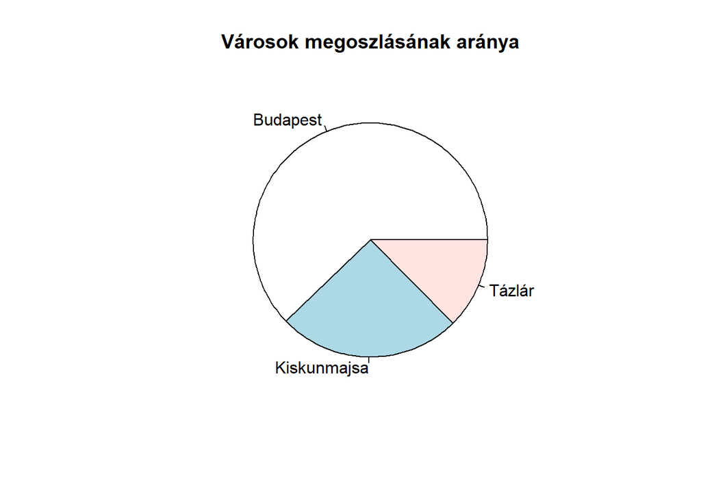

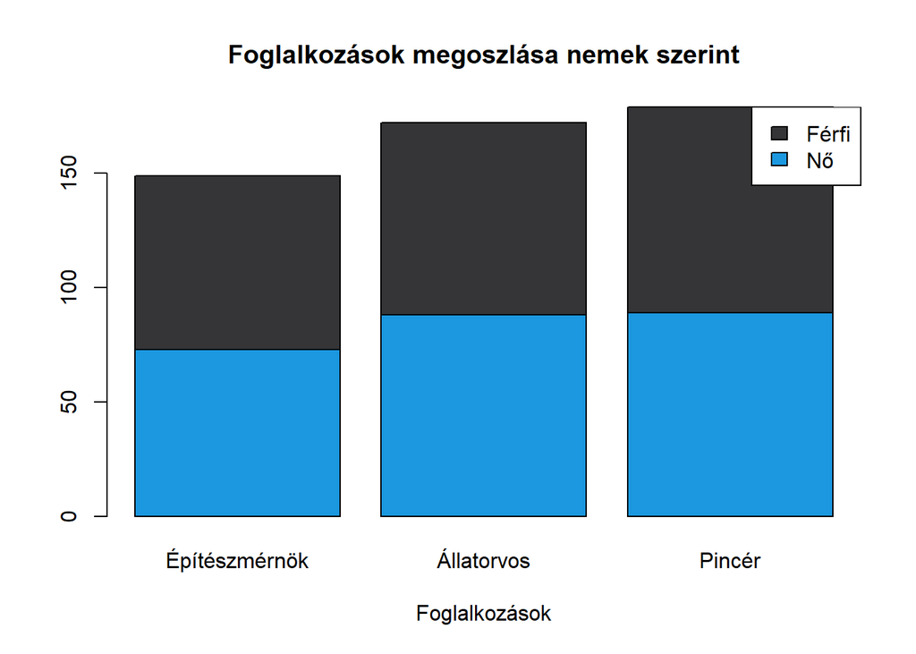

*A női-férfi arány szakmánként (csakúgy, mint összességében) szinte azonos.*

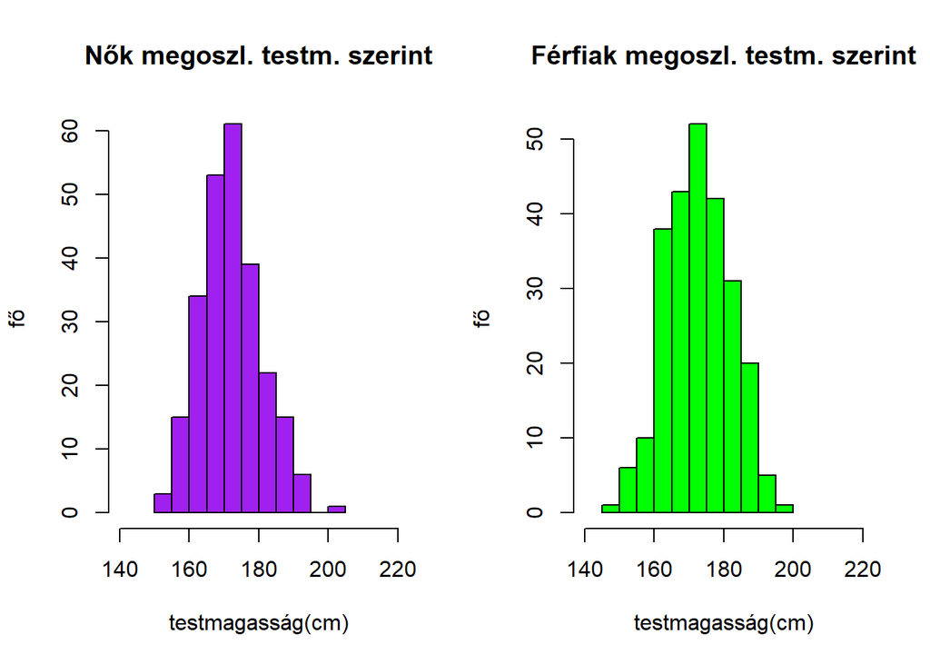

*Hisztogramon ábrázoljuk a testmagasság szerinti megoszlásokat mind nők, mind férfiak esetében.*

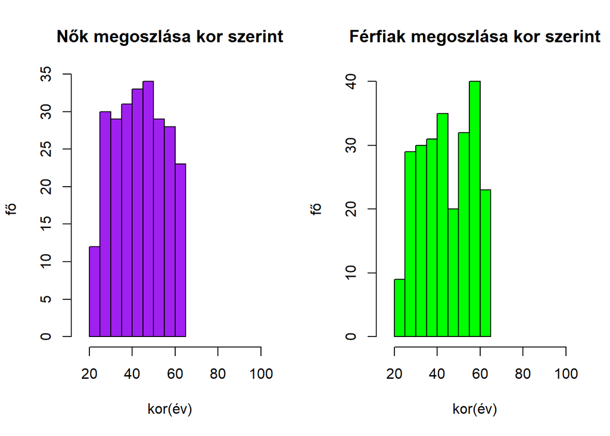

*Hisztogramon ábrázoljuk a kor szerinti megoszlásokat mind nők, mind férfiak esetében.*

**Magasságok átlaga és szórása (mindenki/nők/férfiak):**

```
##          Mindenki        Nők    Férfiak
## Átlag  172.950000 172.566265 173.269076
## Szórás   8.931464   8.700008   9.114189
```

**Magasságok 95%-os alsó és felső intervalluma (mindenki/nők/férfiak):**

```
##              Mindenki      Nők  Férfiak
## 95%-os alsó  172.1671 171.4857 172.1370
## 95%-os felső 173.7329 173.6469 174.4011
```

### BOXPLOTOK

**Testmagasság~Nem**

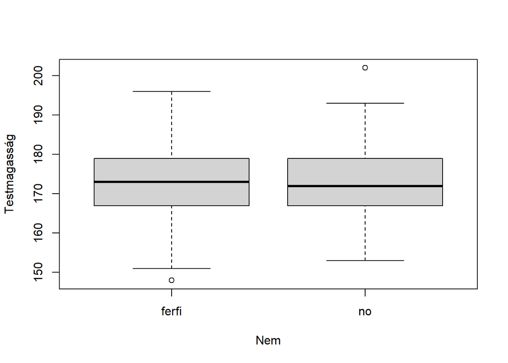

**Kor~Nem**

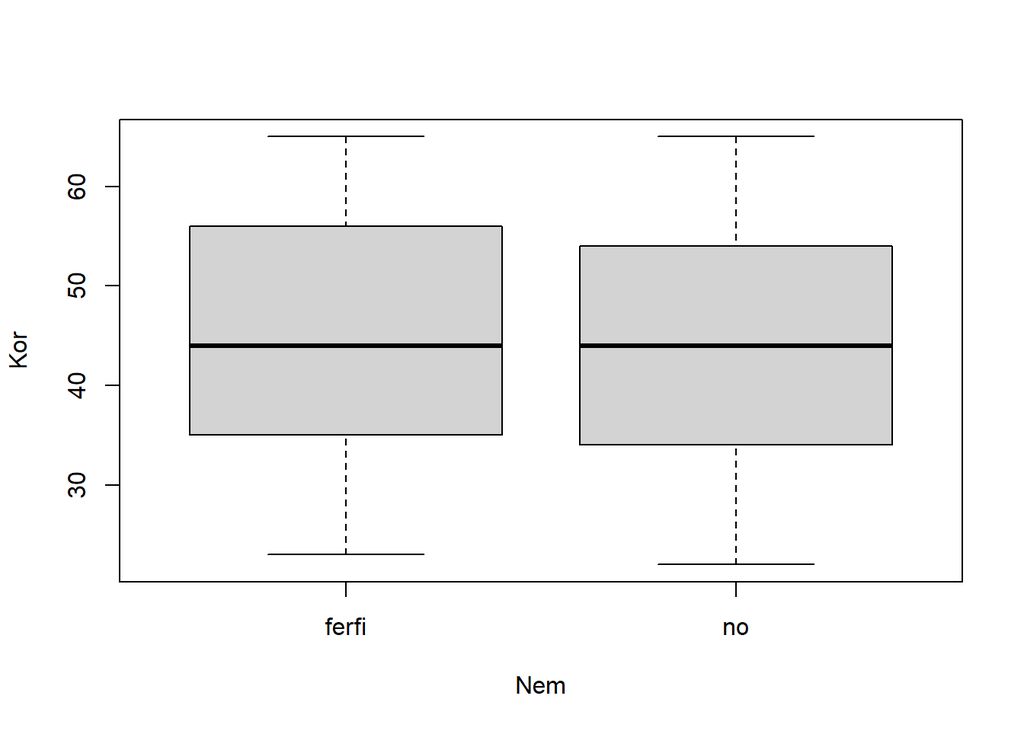

*A férfiak és nők korának átlaga nagyjából megegyezik, a nőknél a felső-, illetve alsó-kvartilis határa is valamivel lejjebb helyezkedik el.*

**Jövedelem~Nem**

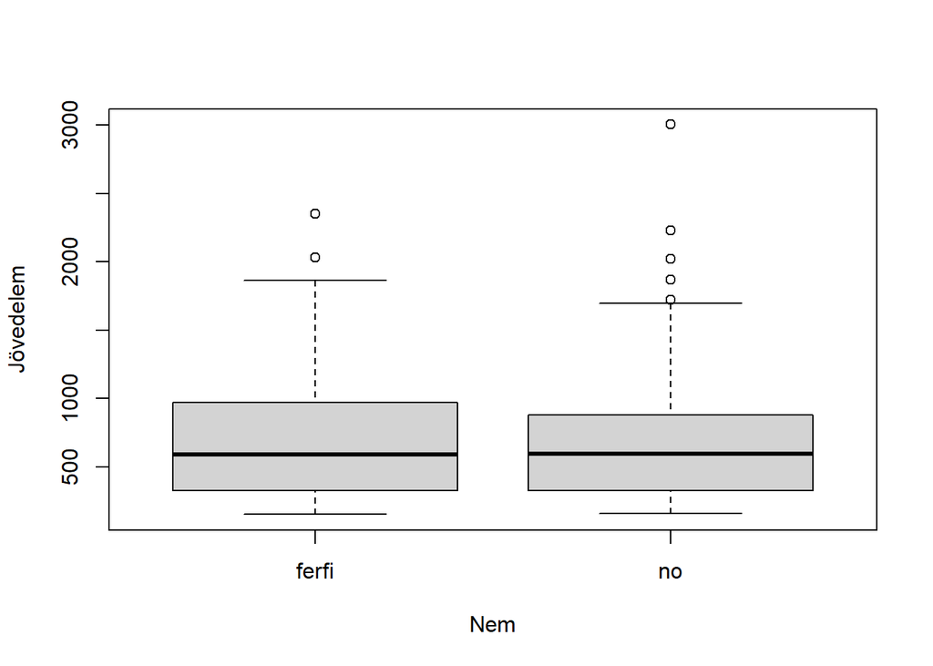

**Jövedelem~Város**

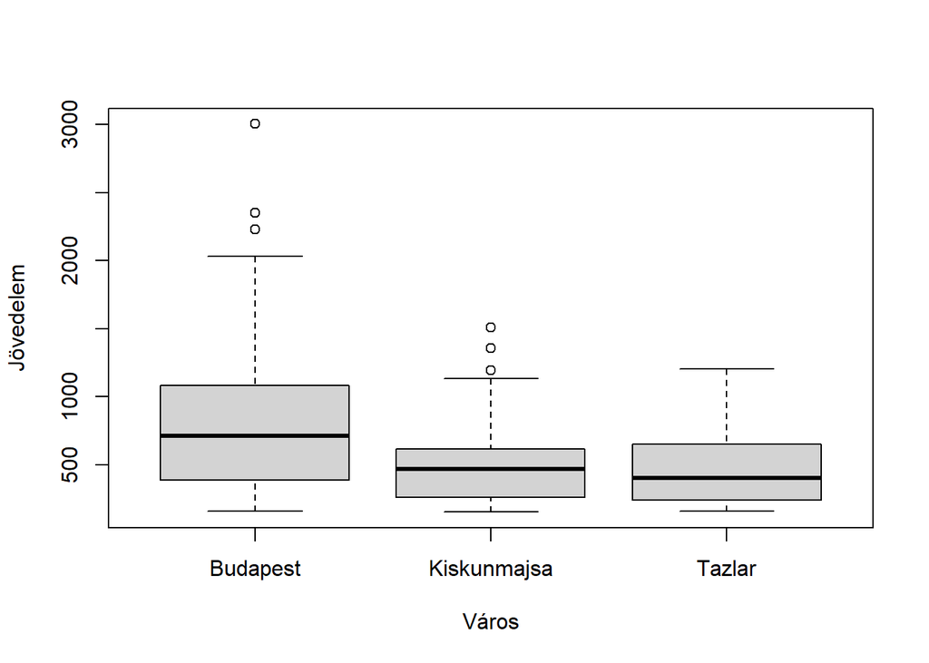

*Egyértelműen kirajzolódik, hogy Budapest fizetései mennyivel a másik két város előtt járnak. A felső kvartilis a másik két város maximumával hozható párhuzamba. Természetesen az átlagfizetés is jóval magasabb, mint máshol.*

**Jövedelem~Foglalkozás**

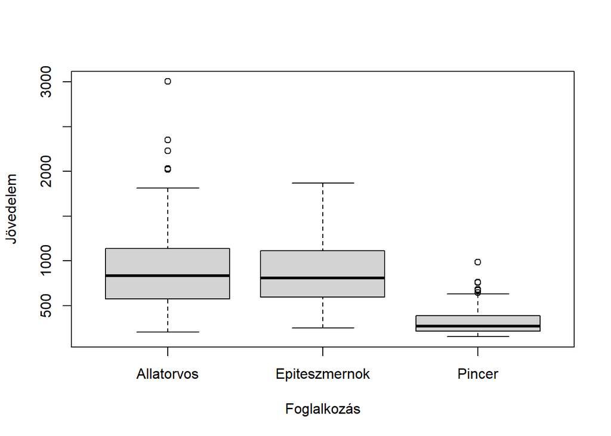

## HIPOTÉZISVIZSGÁLAT

### Nők és férfiak jövedelmének vizsgálata

H0 hipotézis: nők és férfiak jövedelme egyenlő

H1 hipotézis: nők és férfiak jövedelme nem egyenlő

```
##
##  F test to compare two variances
##
## data:  jovedelemF and jovedelemN
## F = 1.0122, num df = 248, denom df = 248, p-value = 0.9237
## alternative hypothesis: true ratio of variances is not equal to 1
## 95 percent confidence interval:
##  0.7887425 1.2990877
## sample estimates:
## ratio of variances
##           1.012248
```

Jól látható, hogy számolhatunk egyenlő szórással. (p-value = 0.9237 > 0.05, ha 95%-os konfidencia-intervallummal számolunk)

```
##
##  Two Sample t-test
##
## data:  jovedelemF and jovedelemN
## t = 0.33705, df = 496, p-value = 0.7362
## alternative hypothesis: true difference in means is not equal to 0
## 90 percent confidence interval:
##  -51.13894  77.43613
## sample estimates:
## mean of x mean of y
##  690.4779  677.3293
```

Mivel p = 0.7362 > 0.1 (90%-os konfidencia intervallum esetén) tehát a nullhipotézist nem tudjuk elvetni, vagyis nem tudjuk tagadni, hogy a férfiak és a nők egyenlően keresnek.

### Építészmérnökök és állatorvosok jövedelmének vizsgálata

H0 hipotézis: építészmérnökök és állatorvosok jövedelme egyenlő

H1 hipotézis: építészmérnökök és állatorvosok jövedelme nem egyenlő

```
##
##  F test to compare two variances
##
## data:  epiteszmernokokJov and allatorvosokJov
## F = 0.7536, num df = 147, denom df = 170, p-value = 0.07833
## alternative hypothesis: true ratio of variances is not equal to 1
## 95 percent confidence interval:
##  0.5518913 1.0327595
## sample estimates:
## ratio of variances
##          0.7536041
```

Jól látható, hogy p-value = 0.07833 > 0.05, 95%-os konfidencia-intervallum választás esetén tehét számolhatunk egyenlő szórással.

```
##
##  Two Sample t-test
##
## data:  epiteszmernokokJov and allatorvosokJov
## t = -0.30919, df = 317, p-value = 0.7574
## alternative hypothesis: true difference in means is not equal to 0
## 95 percent confidence interval:
##  -104.38319   76.03066
## sample estimates:
## mean of x mean of y
##  880.3851  894.5614
```

Mivel p nagy (p = 0.7574 > 0.05), a nullhipotézist nem tudjuk elvetni, vagyis nem tudjuk tagadni, hogy az építészmérnökök és állatorvosok jövedelme egyenlő.

### Állatorvosok és pincérek jövedelmének vizsgálata

H0 hipotézis: pincérek legalább annyit keresnek, mint az állatorvosok (pincér >= állatorvos)

H1 hipotézis: állatorvosok többet keresnek, mint a pincérek (pincér < állatorvos)

```
##
##  F test to compare two variances
##
## data:  allatorvosokJov and pincerekJov
## F = 9.1982, num df = 170, denom df = 177, p-value < 2.2e-16
## alternative hypothesis: true ratio of variances is not equal to 1
## 95 percent confidence interval:
##   6.826575 12.405003
## sample estimates:
## ratio of variances
##           9.198183
```

Mivel p nagyon kicsi (p < 2.2e-16), ezért nem számolhatunk egyenlő szórással, tehát Welch-próbát alkalmazunk.

```
##
##  Welch Two Sample t-test
##
## data:  allatorvosokJov and pincerekJov
## t = 16.587, df = 205.21, p-value < 2.2e-16
## alternative hypothesis: true difference in means is greater than 0
## 95 percent confidence interval:
##  520.8118      Inf
## sample estimates:
## mean of x mean of y
##  894.5614  316.1292
```

Mivel p nagyon kicsi (p < 2.2e-16), ezért a nullhipotézist elvetjük, tehát az első hipotézist elfogadjuk, miszerint az állatorvosok többet keresnek, mint a pincérek.

### Építészmérnökök és pincérek jövedelmének vizsgálata

H0 hipotézis: pincérek legalább annyit keresnek, mint az építészmérnökök (pincér >= építészmérnök)

H1 hipotézis: építészmérnökök többet keresnek, mint a pincérek (pincér < építészmérnök)

```
##
##  F test to compare two variances
##
## data:  epiteszmernokokJov and pincerekJov
## F = 6.9318, num df = 147, denom df = 177, p-value < 2.2e-16
## alternative hypothesis: true ratio of variances is not equal to 1
## 95 percent confidence interval:
##  5.093482 9.476276
## sample estimates:
## ratio of variances
##           6.931788
```

Mivel p nagyon kicsi (p < 2.2e-16), ezért nem számolhatunk egyenlő szórással, tehát Welch-próbát alkalmazunk.

```
##
##  Welch Two Sample t-test
##
## data:  epiteszmernokokJov and pincerekJov
## t = 17.22, df = 182.2, p-value < 2.2e-16
## alternative hypothesis: true difference in means is greater than 0
## 95 percent confidence interval:
##  510.0818      Inf
## sample estimates:
## mean of x mean of y
##  880.3851  316.1292
```

Mivel p nagyon kicsi (p < 2.2e-16), ezért a nullhipotézist elvetjük, tehát az első hipotézist elfogadjuk, miszerint az építészmérnökök többet keresnek, mint a pincérek.

```
## A korcsoportok meghatározásához a quantile()-t használom, hogy a csoportok létszámában ne legyen szignifikáns különbség.
## group1:  - 32
## group2:  32 - 40
## group3:  40 - 48.4
## group4:  48.4 - 56
## group5:  56 - 65
```

### Group1 (legfiatalabbak) és group5 (legidősebbek) jövedelmének vizsgálata

H0 hipotézis: group1 tagjai legalább annyit keresnek, mint a group5 tagjai (group1 >= group5)

H1 hipotézis: group5 tagjai többet keresnek, mint a group1 tagjai (group1 < group5)

```
##
##  F test to compare two variances
##
## data:  group1 and group5
## F = 0.17394, num df = 100, denom df = 97, p-value < 2.2e-16
## alternative hypothesis: true ratio of variances is not equal to 1
## 95 percent confidence interval:
##  0.1168416 0.2586397
## sample estimates:
## ratio of variances
##          0.1739444
```

Mivel p nagyon kicsi (p < 2.2e-16), ezért nem számolhatunk egyenlő szórással, tehát Welch-próbát alkalmazunk.

```
##
##  Welch Two Sample t-test
##
## data:  group1 and group5
## t = -8.6949, df = 128.94, p-value = 6.857e-15
## alternative hypothesis: true difference in means is less than 0
## 95 percent confidence interval:
##       -Inf -420.7629
## sample estimates:
## mean of x mean of y
##  439.4356  959.2449
```

Mivel p nagyon kicsi (p = 6.857e-15), ezért H0-t elvetjük és H1-t elfogadjuk. Ezek alapján állíthatjuk, hogy a group5 tagjai többet keresnek, mint a group1 tagjai.

### Group4 és group5 jövedelmének vizsgálata

H0 hipotézis: group4 tagjai legalább annyit keresnek, mint a group5 tagjai (group4 >= group5)

H1 hipotézis: group5 tagjai többet keresnek, mint a group4 tagjai (group4 < group5)

```
##
##  F test to compare two variances
##
## data:  group4 and group5
## F = 0.5927, num df = 99, denom df = 97, p-value = 0.01015
## alternative hypothesis: true ratio of variances is not equal to 1
## 95 percent confidence interval:
##  0.3978068 0.8823415
## sample estimates:
## ratio of variances
##          0.5926964
```

Mivel p nagyon kicsi (p = 0.01015), ezért nem számolhatunk egyenlő szórással, tehát Welch-próbát alkalmazunk.

```
##
##  Welch Two Sample t-test
##
## data:  group4 and group5
## t = -2.9239, df = 182.19, p-value = 0.001948
## alternative hypothesis: true difference in means is less than 0
## 95 percent confidence interval:
##       -Inf -88.34748
## sample estimates:
## mean of x mean of y
##  755.9500  959.2449
```

Mivel p nagyon kicsi (p = 0.001948), ezért H0-t elvetjük és H1-t elfogadjuk. Ezek alapján állíthatjuk, hogy a group5 tagjai többet keresnek, mint a group4 tagjai.

### Group2 és group3 jövedelmének vizsgálata

H0 hipotézis: group2 tagjai legalább annyit keresnek, mint a group3 tagjai (group2 >= group3)

H1 hipotézis: group3 tagjai többet keresnek, mint a group2 tagjai (group2 < group3)

```
##
##  F test to compare two variances
##
## data:  group2 and group3
## F = 0.79661, num df = 99, denom df = 95, p-value = 0.2637
## alternative hypothesis: true ratio of variances is not equal to 1
## 95 percent confidence interval:
##  0.5332985 1.1879319
## sample estimates:
## ratio of variances
##          0.7966073
```

Mivel p = 0.2637, ezért számolhatunk egyenlő szórással. (=> kétmintás t-próba)

```
##
##  Two Sample t-test
##
## data:  group2 and group3
## t = -1.4161, df = 194, p-value = 0.07917
## alternative hypothesis: true difference in means is less than 0
## 95 percent confidence interval:
##      -Inf 12.63788
## sample estimates:
## mean of x mean of y
##  598.7700  674.4062
```

Mivel p = 0.07917,

95%-os konfidencia intervallum esetén p > 0.05, ezért H0-t nem tudjuk elvetni, vagyis nem tudjuk cáfolni, hogy group2 tagjai legalább annyit keresnek, mint a group3 tagjai.

90%-os konfidencia intervallum esetén p < 0.10, ezért H0-t elvetjük és H1-t elfogadjuk. Vagyis állíthatjuk a group3 tagjai többet keresnek, mint a group2 tagjai.

### Group1 és group2 jövedelmének vizsgálata

H0 hipotézis: group1 tagjai legfeljebb annyit keresnek, mint a group2 tagjai (group1 <= group2)

H1 hipotézis: group1 tagjai többet keresnek, mint a group2 tagjai (group1 > group2)

```
##
##  F test to compare two variances
##
## data:  group1 and group2
## F = 0.41972, num df = 100, denom df = 99, p-value = 2.068e-05
## alternative hypothesis: true ratio of variances is not equal to 1
## 95 percent confidence interval:
##  0.2826314 0.6230506
## sample estimates:
## ratio of variances
##          0.4197185
```

Mivel p nagyon kicsi (p = 2.068e-05), ezért nem számolhatunk egyenlő szórással, tehát Welch-próbát alkalmazunk.

```
##
##  Welch Two Sample t-test
##
## data:  group1 and group2
## t = -3.8001, df = 169.41, p-value = 0.9999
## alternative hypothesis: true difference in means is greater than 0
## 95 percent confidence interval:
##  -228.6811       Inf
## sample estimates:
## mean of x mean of y
##  439.4356  598.7700
```

Mivel p nagy (p = 0.9999), ezért nem tudjuk elvetni H0-t.Vagyis nem tudjuk tagadni, hogy group1 tagjai legfeljebb annyit keresnek, mint a group2 tagjai.

## FÜGGETLENSÉGVIZSGÁLAT

### Kor és jövedelem függetlenségének vizsgálata

A már korábban használt korcsoportok mellett a jövedelmet 3 részre osztom.

```
## A jövedelem szerinti csoportok meghatározásához a quantile()-t használom, hogy a csoportok létszámában ne legyen szignifikáns különbség.
## jövedelemcsop1:  - 401.67
## jövedelemcsop2:  401.67 - 767.68
## jövedelemcsop3:  767.68 - 3003
```

```
## A korcsoportok mégegyszer:
## group1:  - 32
## group2:  32 - 40
## group3:  40 - 48.4
## group4:  48.4 - 56
## group5:  56 - 65
```

H0: a kor és a jövedelem függetlenek

H1: nem függetlenek

```
##             jövedelemcsop1 jövedelemcsop2 jövedelemcsop3
## korcsoprot1             51             41             10
## korcsoport2             40             29             32
## korcsoport3             28             39             30
## korcsoport4             29             30             42
## korcsoport5             17             26             56
```

```
##
##  Pearson's Chi-squared test
##
## data:  tablazatKJ
## X-squared = 58.76, df = 8, p-value = 8.155e-10
```

Mivel p nagyon kicsi (p = 8.155e-10), ezért elutasítjuk H0-t, vagyis a kor és a jövedelem nem függetlenek.

### Foglalkozás és jövedelem függetlenségének vizsgálata

```
## A jövedelem szerinti csoportok mégegyszer:
## jövedelemcsop1:  - 401.67
## jövedelemcsop2:  401.67 - 767.68
## jövedelemcsop3:  767.68 - 3003
```

```
## Foglalkozás szerinti csoportok:
## Építészmérnök Állatorvos Pincér
```

H0: a foglalkozás és a jövedelem függetlenek

H1: nem függetlenek

```
##               jövedelemcsop1 jövedelemcsop2 jövedelemcsop3
## építészmérnök             11             61             77
## állatorvos                16             64             92
## pincér                   138             40              1
```

```
##
##  Pearson's Chi-squared test
##
## data:  tablazatFJ
## X-squared = 266.08, df = 4, p-value < 2.2e-16
```

Mivel p nagyon kicsi (p < 2.2e-16), ezért elutasítjuk H0-t, vagyis a foglalkozás és a jövedelem nem függetlenek.

### Foglalkozás és kor függetlenségének vizsgálata

```
## A korcsoportok mégegyszer:
## group1:  - 32
## group2:  32 - 40
## group3:  40 - 48.4
## group4:  48.4 - 56
## group5:  56 - 65
```

```
## Foglalkozás szerinti csoportok:
## Építészmérnök Állatorvos Pincér
```

H0: a foglalkozás és a kor függetlenek

H1: nem függetlenek

```
##               korcsoprt1 korcsoport2 korcsoport3 korcsoport4 korcsoport5
## építészmérnök         23          33          29          30          34
## állatorvos            32          29          36          36          39
## pincér                47          39          32          35          26
```

```
##
##  Pearson's Chi-squared test
##
## data:  tablazatFK
## X-squared = 10.958, df = 8, p-value = 0.2041
```

Mivel p nagy (p = 0.2041), ezért nem tudjuk elvetni H0-t, vagyis a a foglalkozás és a kor függetlenek.

## NORMALITÁSVIZSGÁLAT

### Jövedelem normalitás vizsgálata

```
##
##  Shapiro-Wilk normality test
##
## data:  jovedelem
## W = 0.90777, p-value < 2.2e-16
```

A shapiro testet alkalmazva azt kaptuk, hogy p nagyon kicsi (p < 2.2e-16), tehát a jövedelem nem normális eloszlású.

### Kor normalitás vizsgálata

```
##
##  Shapiro-Wilk normality test
##
## data:  kor
## W = 0.95957, p-value = 1.758e-10
```

A shapiro testet alkalmazva azt kaptuk, hogy p nagyon kicsi (p = 1.758e-10), tehát a kor nem normális eloszlású.

### Testmagasság normalitás vizsgálata

```
##
##  Shapiro-Wilk normality test
##
## data:  testmagassag
## W = 0.99363, p-value = 0.03347
```

A shapiro testet alkalmazva azt kaptuk, hogy p kicsi (p = 0.03347), tehát a testmagasság nem normális eloszlású (95%-os konfidencia intervallummal számolva).

### Férfiak testmagasságának normalitás vizsgálata

```
##
##  Shapiro-Wilk normality test
##
## data:  testmagassagF
## W = 0.99397, p-value = 0.4209
```

A shapiro testet alkalmazva azt kaptuk, hogy p nagy (p = 0.4209), tehát a férfiak testmagassága normális eloszlású.

## LINEÁRIS MODELLEK JÖVEDELEMRE

### Kor szerinti jövedelem

Megvizsgáljuk, hogy milyen hatással van a kor a jövedelemre.

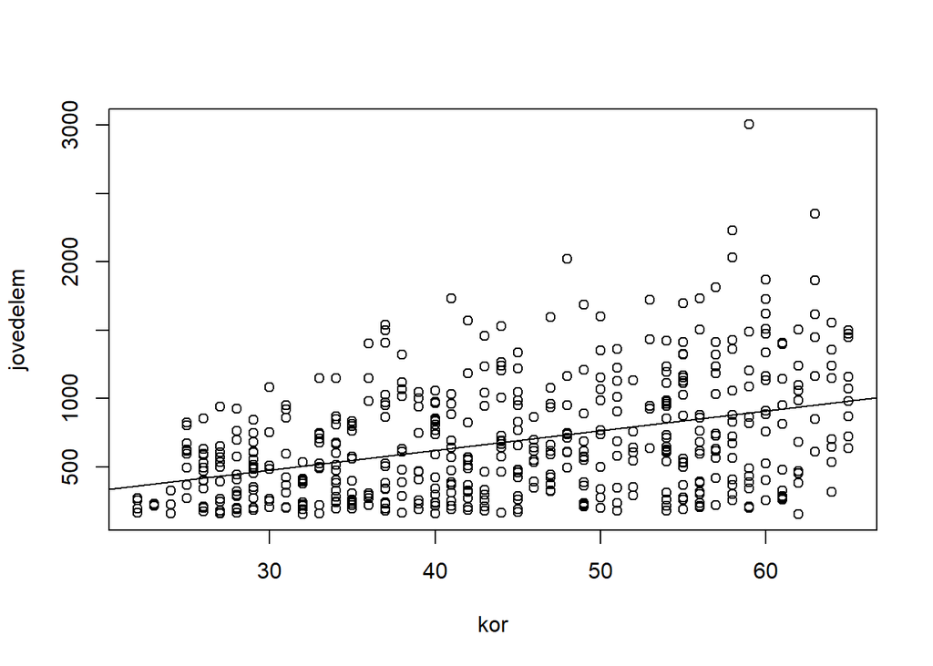

```
##
## Call:
## lm(formula = jovedelem ~ kor, data = JavitottValtozat)
##
## Residuals:
##     Min      1Q  Median      3Q     Max
## -786.41 -280.08  -71.21  250.27 2107.08
##
## Coefficients:
##             Estimate Std. Error t value Pr(>|t|)
## (Intercept)   40.571     68.974   0.588    0.557
## kor           14.497      1.504   9.640   <2e-16 ***
## ---
## Signif. codes:  0 '***' 0.001 '**' 0.01 '*' 0.05 '.' 0.1 ' ' 1
##
## Residual standard error: 399.3 on 498 degrees of freedom
## Multiple R-squared:  0.1573, Adjusted R-squared:  0.1556
## F-statistic: 92.94 on 1 and 498 DF,  p-value: < 2.2e-16
```

Az értékekből azt a következtetést tudjuk levonni, hogy a kor valóban hatással van a jövedelemre, kiindulási érték a 40.571 és évenként 14.497-tel növekszik ez az érték. (jovedelem = 40.571 + kor*14.497)

### Testmagasság szerinti jövedelem

Megvizsgáljuk, hogy milyen hatással van a testmagasság a jövedelemre.

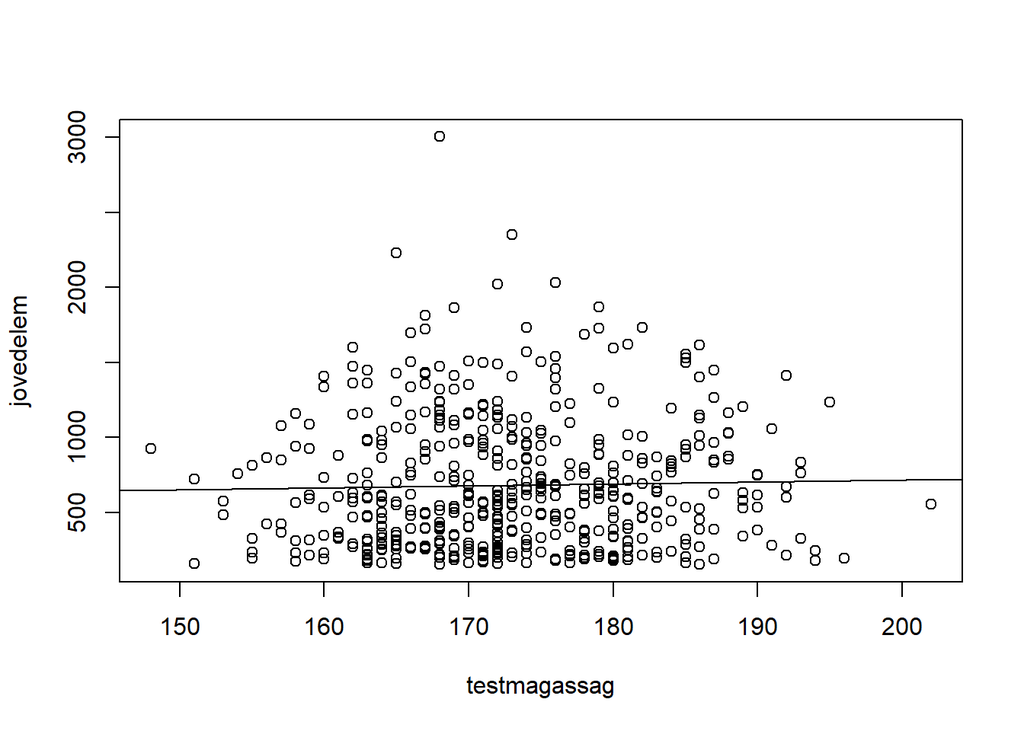

```
##
## Call:
## lm(formula = jovedelem ~ testmagassag, data = JavitottValtozat)
##
## Residuals:
##     Min      1Q  Median      3Q     Max
## -547.01 -355.22  -88.58  263.93 2326.68
##
## Coefficients:
##              Estimate Std. Error t value Pr(>|t|)
## (Intercept)   455.251    377.398   1.206    0.228
## testmagassag    1.316      2.179   0.604    0.546
##
## Residual standard error: 434.8 on 498 degrees of freedom
## Multiple R-squared:  0.0007316,  Adjusted R-squared:  -0.001275
## F-statistic: 0.3646 on 1 and 498 DF,  p-value: 0.5462
```

A p értéke nagyon nagy (p = 0.546), ezért kijelenthető, hogy a testmagasság nincs hatással a jövedelemre. (Ábrán is látható)

### Becslések

**Szakmánként:**

```
##
## Call:
## lm(formula = jovedelemEpiteszmernok ~ korEpiteszmernok + testmagassagEpiteszmernok,
##     data = dfEpiteszmernok)
##
## Coefficients:
##               (Intercept)           korEpiteszmernok
##                  -754.679                     16.122
## testmagassagEpiteszmernok
##                     5.303
```

```
## Egy 178 cm magas 43 éves férfi építészmérnök becsült jövedelme:  855.9797
```

```
##
## Call:
## lm(formula = jovedelemAllatorvos ~ korAllatorvos + testmagassagAllatorvos,
##     data = dfAllatorvos)
##
## Coefficients:
##            (Intercept)           korAllatorvos  testmagassagAllatorvos
##                441.588                  15.665                  -1.576
```

```
## Egy 178 cm magas 43 éves férfi állatorvos becsült jövedelme:  842.5798
```

```
##
## Call:
## lm(formula = jovedelemPincer ~ korPincer + testmagassagPincer,
##     data = dfPincer)
##
## Coefficients:
##        (Intercept)           korPincer  testmagassagPincer
##           -136.910               2.894               1.899
```

```
## Egy 178 cm magas 43 éves férfi pincér becsült jövedelme:  315.9705
```

Látható, hogy egyidős és azonos magasságú férfiak keresete között mekkora különbséget tud okozni a foglalkozás. Míg az építészmérnökök és állatorvosok közel azonos bért várhatnak, addig a pincérek megközelítőleg harmadennyit.

**Városonként:**

```
##
## Call:
## lm(formula = jovedelemBudapest ~ korBudapest + testmagassagBudapest,
##     data = dfBudapest)
##
## Coefficients:
##          (Intercept)           korBudapest  testmagassagBudapest
##             -208.636                15.557                 1.841
```

```
## Egy Budapest városban élő 178 cm magas 43 éves férfi becsült jövedelme:  778.716
```

```
##
## Call:
## lm(formula = jovedelemKiskunmajsa ~ korKiskunmajsa + testmagassagKiskunmajsa,
##     data = dfKiskunmajsa)
##
## Coefficients:
##             (Intercept)           korKiskunmajsa  testmagassagKiskunmajsa
##                198.6303                   8.3584                  -0.5817
```

```
## Egy Kiskunmajsa városban élő 178 cm magas 43 éves férfi becsült jövedelme:  457.3984
```

```
##
## Call:
## lm(formula = jovedelemTazlar ~ korTazlar + testmagassagTazlar,
##     data = dfTazlar)
##
## Coefficients:
##        (Intercept)           korTazlar  testmagassagTazlar
##           -647.980              13.235               3.427
```

```
## Egy Tázlár városban élő 178 cm magas 43 éves férfi becsült jövedelme:  514.0496
```

Látható, hogy a város is fontos tényező, a Budapesten dolgozó férfiak jóval többet keresnek, mint Kiskunmajsán illetve Tázláron tevékenykedő társaik.

Megjegyzendő továbbá, hogy a lineáris modellekre a summary()-t meghívva látjuk, hogy a magasság nem befolyásolja szignifikánsan a jövedelmet, tehát azt elhagyva pontosabb becsléseket tudnánk alkalkmazni.